# MidtermExam

Author

Kyra Guy

## Introduction

The dataset used in this analysis originates from a community health assessment conducted by the University of Southern California’s Global Research Implementation and Training Lab in Lira District, Eastern Uganda. According to the World Health Organization (WHO), mental health disorders currently affect more than one billion people, including one in seven adolescents. However, despite the growing health and economic burden, governments spend only around 2% of their health budgets on these disorders and people with mental health conditions often experience severe human rights violations, discrimination, and stigma. In response to the call for greater attention to mental health challenges in low-income and post-conflict communities, a community-based participatory research (CBPR) study was carried out in Lira District, Uganda in the Spring of 2022.

The political history of Lira District, the epicenter of the decades-long conflict between the Lord’s Resistance Army (LRA) and the Ugandan government, makes for an especially interesting case study of the political and social determinants of mental health of those directly impacted by conflict, and generations growing up in post-conflict communities. Data collected by this study aimed to evaluate the current mental health outcomes of adolescents (14-17 years of age). This dataset has been used previously for other analyses and was submitted for publication in the journal Conflict and Health, published by the British Medical Journal.

Data was collected through an adolescent questionnaire assessing general demographics, physical health status, diet, substance use, violence and risky behaviors, mental health knowledge, and behaviors, Adverse Childhood Experiences Score (ACE-IQ), and WHO-5 Wellbeing Index Scores. Used consistently in research, the ACE-IQ survey is intended to measure some of frequently occurring sources of stress that children may suffer early in life. Questions cover family dysfunction; physical, sexual and emotional abuse and neglect by parents or caregivers; peer violence; witnessing community violence, and exposure to collective violence. Scores have been used as general predictors of future adolescent health outcomes. The WHO Wellbeing Index scores are measured out of 100 and assess current adolescent states of wellbeing, this survey has been used as a screening tool for depression.

The main research question explored through this dataset is how has conflict in Northern Uganda influenced adolescent mental health outcomes, specifically looking at how might factors, such as gender and sub-county, affect ACE-IQ and WHO Wellbeing Index scores among this population.

## Methods

Upon loading the dataset into R, inspection of the head and tail was done to gain a preliminary understanding of the structure and contents. The dataset was then checked for missing values. Missing values did not seem significant enough to drop and were included in the analysis but dropped from visualizations.

The age variable recorded in the dataset was transformed into a dichotomous variable with a value of 1 meaning adolescents were between the ages of 14-15, and 2 meaning they were 16-17. The number of friends respondents reported having while also dichotomized with a 1 being representative of 0-2 friends and a 2 having 3 or more friends.

Exploratory data analysis was conducted by creating summary statistics for each variable of interest. For continuous variables, including the total ACE scores and the WHO Wellbeing Index scores, means, medians, standard deviations, minimum and maximum values were computed. Categorical variables were summarized using frequency tables, displaying counts and percentages for each category. Summary tables were created from summary statistics.

```r
library(data.table)
library(readr)
library(magrittr)
library(dplyr)
library(readxl)
library(writexl)
library(dtplyr)
library(ggplot2)
```

```r
setwd("/Users/kyraguy/Desktop/PhD/PM566")
datafinal <- read_excel("ACEIQData.xlsx")

#head(datafinal)
#tail(datafinal)
```

*Data Wrangling and Cleaning*

```r
#missingvalues
missing_values <- datafinal %>%
  summarise_all(~ sum(is.na(.)))

print(missing_values[missing_values > 0])
```

```
 [1]  1  1  1  1  1  1  1  1  1 39  1  1  1
```

```r
#sumscore
datafinal$acescore <- rowSums(datafinal[, c("q88", "q89", "q90", "q91", "q92", "q93", "q94", "q95", "q96", "q97", "q98", "q99", "q100")], na.rm = TRUE)

#newvariables
datafinal <- datafinal %>%
  mutate(age_category = ifelse(age %in% c(1, 2), 1, ifelse(age %in% c(3, 4), 2, NA)))

datafinal <- datafinal %>%
  mutate(friends_category = ifelse(friends %in% c(1, 2), 1, ifelse(friends %in% c(3, 4), 2, NA)))
```

*Exploratory Data Analysis*

```r
#summary(datafinal)
#summary(acescores)
#summary(wellbeingindex)
#table(datafinal$age_category)
#table(datafinal$school)
#table(datafinal$gender)
#table(datafinal$religion)
#table(datafinal$caretaker)
#table(datafinal$class)
```

```r
#checkforoutliers
acescore <- datafinal$acescore

Q1 <- quantile(acescore, 0.25)
Q3 <- quantile(acescore, 0.75)
IQR_value <- IQR(acescore)

lower_bound <- Q1 - 1.5 * IQR_value
upper_bound <- Q3 + 1.5 * IQR_value

outliers <- acescore < lower_bound | acescore > upper_bound

cat("Number of outliers:", sum(outliers), "\n")
```

```
Number of outliers: 5
```

```r
cat("Outlier values:", acescore[outliers], "\n")
```

```
Outlier values: 12 11 10 10 10
```

```r
wellbeingindex <- datafinal$wellbeingindex

Q1 <- quantile(wellbeingindex, 0.25, na.rm = TRUE)
Q3 <- quantile(wellbeingindex, 0.75, na.rm = TRUE)
IQR_value <- IQR(wellbeingindex, na.rm = TRUE)

lower_bound <- Q1 - 1.5 * IQR_value
upper_bound <- Q3 + 1.5 * IQR_value

outliers <- wellbeingindex < lower_bound | wellbeingindex > upper_bound

cat("Number of outliers:", sum(outliers), "\n")
```

```
Number of outliers: NA
```

```r
cat("Outlier values:", wellbeingindex[outliers], "\n")
```

```
Outlier values: 100 100 100 100 100 100 100 100 100 100 100 100 100 100 NA
```

**Summary Tables**

*Demographics*

```r
library(knitr)

demographics <- datafinal %>%
  select(Subcounty, age_category, gender, religion, peopleinhome, caretaker, school, employed, married)

calculate_freq_perc <- function(variable) {
  freq_table <- table(variable, useNA = "ifany")
  perc_table <- prop.table(freq_table) * 100
  return(data.frame(Frequency = as.numeric(freq_table), Percentage = as.numeric(perc_table)))
}

summary_tables <- lapply(demographics, calculate_freq_perc)

for (i in seq_along(demographics)) {
  cat("Variable:", names(demographics)[i], "\n")
  print(kable(summary_tables[[i]], "markdown"))
  cat("\n")
}
```

```
Variable: Subcounty


| Frequency| Percentage|
|---------:|----------:|
|        72| 23.4527687|
|       141| 45.9283388|
|        93| 30.2931596|
|         1|  0.3257329|

Variable: age_category


| Frequency| Percentage|
|---------:|----------:|
|       189| 61.5635179|
|       117| 38.1107492|
|         1|  0.3257329|

Variable: gender


| Frequency| Percentage|
|---------:|----------:|
|       139| 45.2768730|
|       167| 54.3973941|
|         1|  0.3257329|

Variable: religion


| Frequency| Percentage|
|---------:|----------:|
|       104| 33.8762215|
|       113| 36.8078176|
|         3|  0.9771987|
|        84| 27.3615635|
|         2|  0.6514658|
|         1|  0.3257329|

```

[output cut: 37 more lines]

```
|        41| 13.3550489|
|       265| 86.3192182|
|         1|  0.3257329|

Variable: married


| Frequency| Percentage|
|---------:|----------:|
|        79| 25.7328990|
|       210| 68.4039088|
|        15|  4.8859935|
|         1|  0.3257329|
|         1|  0.3257329|
|         1|  0.3257329|
```

*ACE Score and Score Categories by Gender and Sub-county*

*Gender*

```r
#totalscore

summary_tableacegender <- aggregate(acescore ~ gender, data = datafinal, FUN = summary)

print(summary_tableacegender)
```

```
  gender acescore.Min. acescore.1st Qu. acescore.Median acescore.Mean
1      1      0.000000         1.000000        3.000000      3.071942
2      2      0.000000         2.000000        3.000000      3.586826
  acescore.3rd Qu. acescore.Max.
1         4.000000     10.000000
2         5.000000     12.000000
```

```r
#scorecategories

acecategorygender <- datafinal %>%
  select(gender, abuse2, neglect, violence, familydysfunction)

mean_ace_table <- acecategorygender %>%
  group_by(gender) %>%
  summarise(
    Mean_Abuse2 = mean(abuse2, na.rm = TRUE),
    Mean_Neglect = mean(neglect, na.rm = TRUE),
    Mean_Violence = mean(violence, na.rm = TRUE),
    Mean_FamilyDysfunction = mean(familydysfunction, na.rm = TRUE)
  )

print(mean_ace_table)
```

```
# A tibble: 3 × 5
  gender Mean_Abuse2 Mean_Neglect Mean_Violence Mean_FamilyDysfunction
   <dbl>       <dbl>        <dbl>         <dbl>                  <dbl>
1      1        1.16         1.04         0.439                  0.640
2      2        1.37         1.08         0.467                  0.958
3     NA        0            0            0                      0
```

*Sub-county*

```r
#totalscore

summary_tableace <- aggregate(acescore ~ Subcounty, data = datafinal, FUN = summary)

print(summary_tableace)
```

```
  Subcounty acescore.Min. acescore.1st Qu. acescore.Median acescore.Mean
1         1      0.000000         2.000000        3.000000      3.291667
2         2      0.000000         2.000000        3.000000      3.425532
3         3      0.000000         1.000000        3.000000      3.290323
  acescore.3rd Qu. acescore.Max.
1         5.000000      9.000000
2         5.000000     11.000000
3         5.000000     12.000000
```

```r
#scorecategories
acecategorysubcounty <- datafinal %>%
  select(Subcounty, abuse2, neglect, violence, familydysfunction)

mean_ace_table2 <- acecategorysubcounty %>%
  group_by(Subcounty) %>%
  summarise(
    Mean_Abuse2 = mean(abuse2, na.rm = TRUE),
    Mean_Neglect = mean(neglect, na.rm = TRUE),
    Mean_Violence = mean(violence, na.rm = TRUE),
    Mean_FamilyDysfunction = mean(familydysfunction, na.rm = TRUE)
  )

print(mean_ace_table2)
```

```
# A tibble: 4 × 5
  Subcounty Mean_Abuse2 Mean_Neglect Mean_Violence Mean_FamilyDysfunction
      <dbl>       <dbl>        <dbl>         <dbl>                  <dbl>
1         1        1.21         1.01         0.375                  0.986
2         2        1.33         1.08         0.482                  0.816
3         3        1.24         1.08         0.473                  0.677
4        NA        0            0            0                      0
```

*WHO Wellbeing Index Scores by Gender and Sub-county*

*Gender*

```r
summary_tablegender <- aggregate(wellbeingindex ~ gender, data = datafinal, FUN = summary)

print(summary_tablegender)
```

```
  gender wellbeingindex.Min. wellbeingindex.1st Qu. wellbeingindex.Median
1      1            20.00000               36.00000              40.00000
2      2            20.00000               36.00000              40.00000
  wellbeingindex.Mean wellbeingindex.3rd Qu. wellbeingindex.Max.
1            46.87770               52.00000           100.00000
2            49.62874               62.00000           100.00000
```

*Subcounty*

```r
summary_tablenew <- aggregate(wellbeingindex ~ Subcounty, data = datafinal, FUN = summary)

print(summary_tablenew)
```

```
  Subcounty wellbeingindex.Min. wellbeingindex.1st Qu. wellbeingindex.Median
1         1            20.00000               36.00000              40.00000
2         2            20.00000               40.00000              44.00000
3         3            20.00000               32.00000              40.00000
  wellbeingindex.Mean wellbeingindex.3rd Qu. wellbeingindex.Max.
1            47.66667               57.00000           100.00000
2            50.72340               64.00000           100.00000
3            45.37634               52.00000           100.00000
```

**Analysis**

```r
cor_data <- datafinal %>%
  select(acescore, wellbeingindex, age_category, friends_category, gender)

cor_matrix <- cor(cor_data, use = "complete.obs")
print(cor_matrix)
```

```
                    acescore wellbeingindex age_category friends_category
acescore          1.00000000    -0.00538538   0.09748182      -0.09914566
wellbeingindex   -0.00538538     1.00000000  -0.06126094       0.05178595
age_category      0.09748182    -0.06126094   1.00000000      -0.06771660
friends_category -0.09914566     0.05178595  -0.06771660       1.00000000
gender            0.11720905     0.06768606  -0.10606310      -0.12794864
                      gender
acescore          0.11720905
wellbeingindex    0.06768606
age_category     -0.10606310
friends_category -0.12794864
gender            1.00000000
```

```r
ace_by_subcounty <- datafinal %>%
  group_by(Subcounty) %>%
  summarise(mean_ace_score = mean(acescore, na.rm = TRUE))

print(ace_by_subcounty)
```

```
# A tibble: 4 × 2
  Subcounty mean_ace_score
      <dbl>          <dbl>
1         1           3.29
2         2           3.43
3         3           3.29
4        NA           0
```

```r
ace_by_gender <- datafinal %>%
  group_by(gender) %>%
  summarise(mean_ace_score = mean(acescore, na.rm = TRUE),
            median_ace_score = median(acescore, na.rm = TRUE),
            sd_ace_score = sd(acescore, na.rm = TRUE))

print(ace_by_gender)
```

```
# A tibble: 3 × 4
  gender mean_ace_score median_ace_score sd_ace_score
   <dbl>          <dbl>            <dbl>        <dbl>
1      1           3.07                3         2.05
2      2           3.59                3         2.28
3     NA           0                   0        NA
```

**Visualization**

Histograms were used to compare ACE-IQ and WHO Wellbeing index scores between genders and Sub-county.

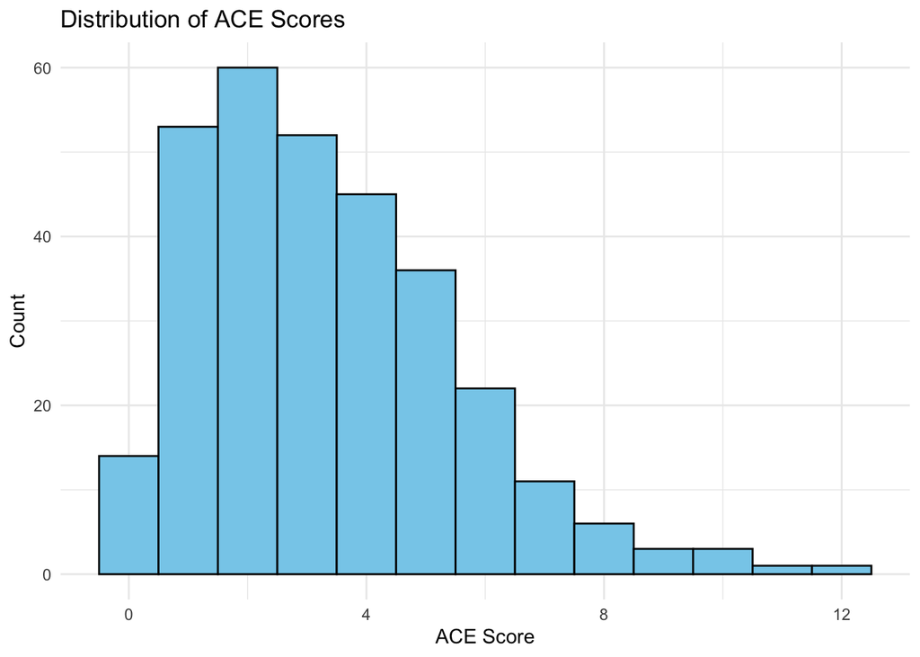

```r
#histograms
filtered_data <- datafinal[!is.na(datafinal$acescore), ]
ace_histogram <- ggplot(filtered_data, aes(x = acescore)) +
  geom_histogram(binwidth = 1, fill = "skyblue", color = "black") +
  labs(title = "Distribution of ACE Scores",
       x = "ACE Score", y = "Count") +
  theme_minimal()
print(ace_histogram)
```

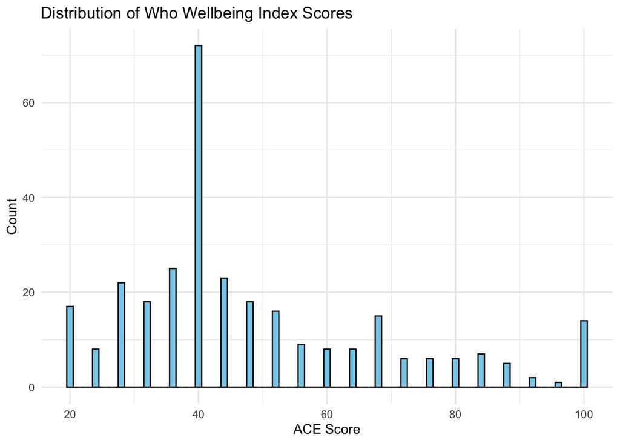

```r
filtered_data <- datafinal[!is.na(datafinal$wellbeingindex), ]
WHO_histogram <- ggplot(filtered_data, aes(x = wellbeingindex)) +
  geom_histogram(binwidth = 1, fill = "skyblue", color = "black") +
  labs(title = "Distribution of Who Wellbeing Index Scores",
       x = "ACE Score", y = "Count") +
  theme_minimal()
print(WHO_histogram)
```

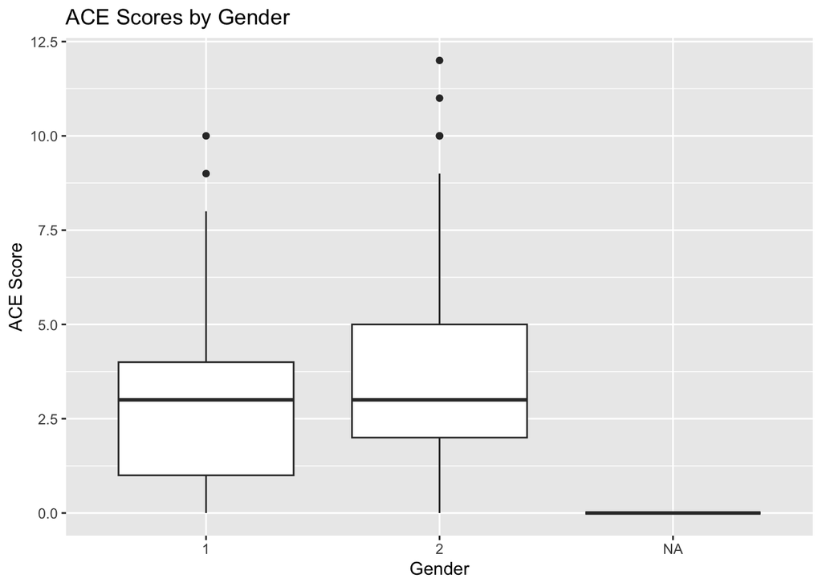

```r
#boxplots

datafinal %>%
  filter(!is.na(acescore)) %>%
  ggplot(aes(x = as.factor(gender), y = acescore)) +
  geom_boxplot() +
  labs(title = "ACE Scores by Gender", x = "Gender", y = "ACE Score")
```

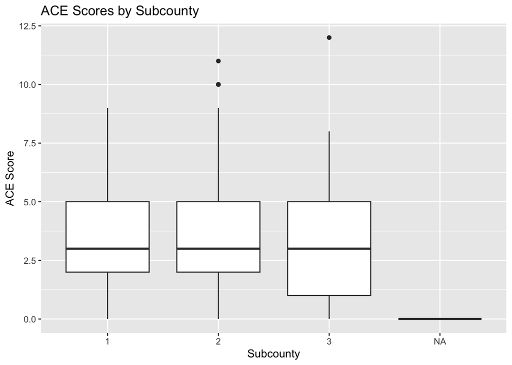

```r
datafinal %>%
  filter(!is.na(acescore)) %>%
  ggplot(aes(x = as.factor(Subcounty), y = acescore)) +
  geom_boxplot() +
  labs(title = "ACE Scores by Subcounty", x = "Subcounty", y = "ACE Score")
```

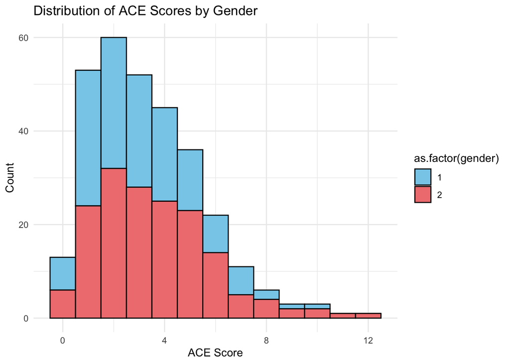

```r
#ACEhistograms
filtered_data <- datafinal[!is.na(datafinal$acescore) & !is.na(datafinal$gender), ]

ggplot(filtered_data, aes(x = acescore, fill = as.factor(gender))) +
  geom_histogram(binwidth = 1, position = "stack", color = "black") +
  labs(title = "Distribution of ACE Scores by Gender",
       x = "ACE Score", y = "Count") +
  scale_fill_manual(values = c("skyblue", "lightcoral")) +
  theme_minimal()
```

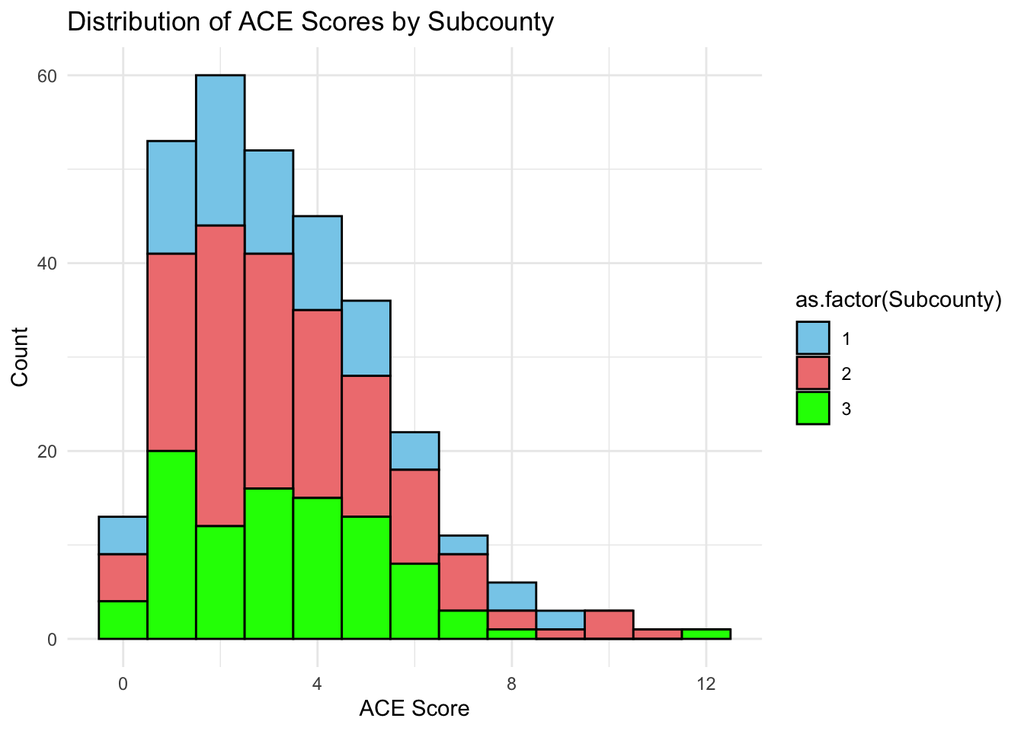

```r
filtered_data2 <- datafinal[!is.na(datafinal$acescore) & !is.na(datafinal$Subcounty), ]

ggplot(filtered_data2, aes(x = acescore, fill = as.factor(Subcounty))) +
  geom_histogram(binwidth = 1, position = "stack", color = "black") +
  labs(title = "Distribution of ACE Scores by Subcounty",
       x = "ACE Score", y = "Count") +
  scale_fill_manual(values = c("skyblue", "lightcoral", "green")) +
  theme_minimal()
```

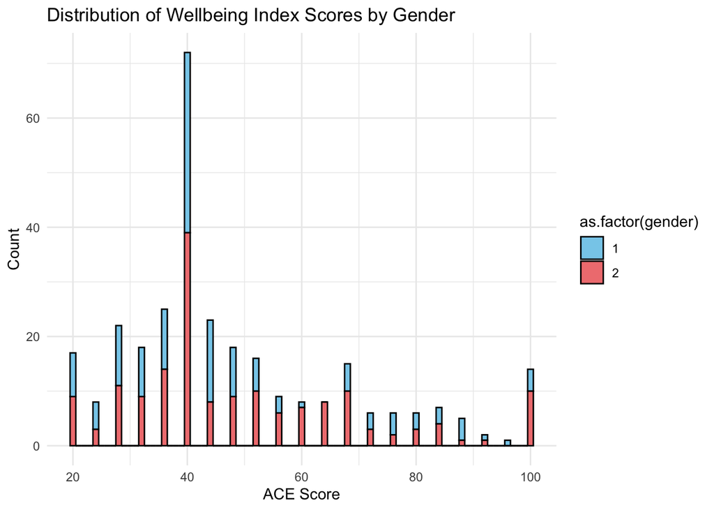

```r
#Wellbeinghistograms
filtered_data3 <- datafinal[!is.na(datafinal$wellbeingindex) & !is.na(datafinal$gender), ]

ggplot(filtered_data3, aes(x = wellbeingindex, fill = as.factor(gender))) +
  geom_histogram(binwidth = 1, position = "stack", color = "black") +
  labs(title = "Distribution of Wellbeing Index Scores by Gender",
       x = "ACE Score", y = "Count") +
  scale_fill_manual(values = c("skyblue", "lightcoral")) +
  theme_minimal()
```

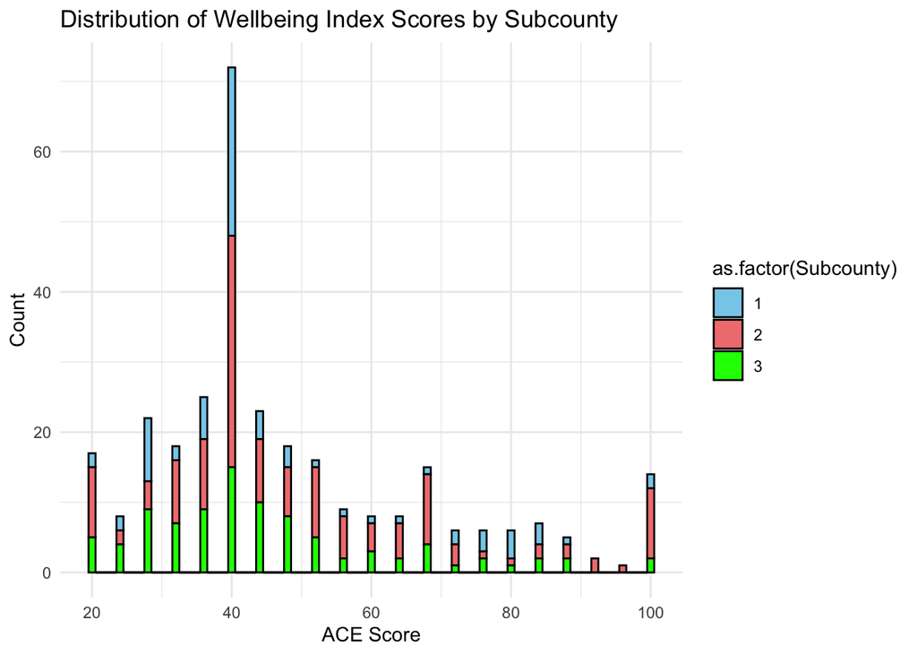

```r
filtered_data4 <- datafinal[!is.na(datafinal$wellbeingindex) & !is.na(datafinal$Subcounty), ]

ggplot(filtered_data4, aes(x = wellbeingindex, fill = as.factor(Subcounty))) +
  geom_histogram(binwidth = 1, position = "stack", color = "black") +
  labs(title = "Distribution of Wellbeing Index Scores by Subcounty",
       x = "ACE Score", y = "Count") +
  scale_fill_manual(values = c("skyblue", "lightcoral", "green")) +
  theme_minimal()
```

# Results

The final dataset had 33 variables and 307 observations. Data were collected from 307 adolescents living in the households in three sub-counties in the Lira district of Uganda.

**Demographics**

Amongst the surveyed youth, 45.42% were male and 54.58% were female, the majority of which (61.8%) were 14 and 15 years old and enrolled in school (87.5%). The youth primarily shared their sleeping space with other family members, and 64.17% of youth indicated that their mother was their primary caretaker. Most of the respondents listed their mother (64.38%) or father (31.37%) as their primary caretaker. The three most prominent religious belief systems were Roman Catholic (36.93%), Anglican (33.93%), and Pentecostal (27.45%).

**Adverse Childhood Experience and WHO Wellbeing Index Scores**

**Conclusions**

The study results indicate that adolescents throughout the Lira District in northern Uganda suffer from poor mental health, and point to multiple politically relevant issues linked to mental health outcomes.

The adolescents surveyed have no living memory of the war, however, they do have memories of the immediate aftermath, have grown up in communities struggling to rebuild post-conflict, and have been raised by parents who likely suffered directly. The high levels of verbal abuse, physical abuse, neglect, and family dysfunction reported are likely in part due to trauma-induced mental health conditions among parents and other caretakers. Poor adolescent wellness scores could also reflect intergenerational trauma, which also places them at increased risk for mental illness and other chronic diseases.